# 1_introduction slides

### Review of Basic Probability Concepts

Probability lets us talk efficiently about things that we are uncertain about.

- What will Amazon’s sales be next quarter?
- What will the return be on my stocks next year?
- How often will users click on a particular Google ad?

*All these involve estimating or predicting unknowns!!*

### Random Variables

- Random Variables are numbers that we are not sure about.
- There's a list of potential outcomes.
- We assign probabilities to each outcome.

Example: Suppose that we are about to toss two coins.

- Let $X$ denote the number of heads.
- We call $X$ the random variable that stands for the potential outcome.

### Probability

Probability is a language designed to help us communicate about uncertainty.

We assign a number between $0$ and $1$ measuring how likely that event is to occur

It's immensely useful, and there's only a few basic rules.

1. If an event $A$ is certain to occur, it has probability $1$, denoted $P(A)=1$
2. Either an event $A$ occurs or it does not. $$\begin{aligned} P(\mbox{not A}) = 1 - P(\mbox{A}) \end{aligned}$$
3. If two events are mutually exclusive (both cannot occur simultaneously) then $P( \mbox{A or B} ) = P(A) +P(B)$
4. Conditional probability $P( \mbox{A and B} ) = P( A| B) P(B)$

### Probability Distribution

We describe the behavior of random variables with a Probability Distribution

Suppose we are about to toss two coins.

Let $X$ denote the number of heads. $$ X = \left\{ \begin{array}{l} 0 \; with \; prob. \; 1/4\\ 1 \; with \; prob. \; 1/2\\ 2 \; with \; prob. \; 1/4 \end{array} \right. $$

$X$ is called a Discrete Random Variable

Question: What is $Pr (X=0)$? How about $Pr (X \geq 1 )$?

### Pete Rose Hitting Streak

Pete Rose of the Cincinnati Reds set a National League record of hitting safely in $44$ consecutive games ...

- Rose was a $300$ hitter.

  Assume he comes to bat $4$ times each game.
- Each at bat is assumed to be independent, i.e., the current at bat doesn’t affect the outcome of the next.

Joe DiMaggio’s record is $56$! His batting average was $.325$

### Pete Rose Hitting Streak

Let $A_i$ denote the event that "Rose hits safely in the ith game''

$Pr ( {\rm Rose \; Hits \; Safely \; in \; 44 \; consecutive \; games} ) =$

$P ( A_1 \; \text{and} \; A_2 \ldots \text{and} \; A_{44} ) = P ( A_1 ) P ( A_2 ) \ldots P ( A_{44} )$

We now need to find $P(A_i) \ldots$ where $\mathbb{P} (A_i ) = 1 - \mathbb{P} ( \text{not} \; A_i )$

$$\begin{aligned} P ( A_1 ) & = 1 - P ( {\rm not} \; A_1 ) \\ & = 1 - P ( {\rm Rose \; makes \; 4 \; outs } ) \\ & = 1 - ( 0.7)^4 = 0.76\end{aligned}$$

So for the winning streak we have $(0.76)^{44} = 0.0000057$ !!!

### Pete Rose Hitting Streak

There three are basic inferences

- This means that the odds for a particular player as good as Pete Rose starting a hitting streak today are $175,470$ to $1$
- Doesn't mean that the run of $44$ won't be beaten by some player at some time: the Law of Very Large Numbers
- Joe DiMaggio's record is 56!!!!

It's going to be hard to beat.

### New England Patriots and Coin Tossing

Patriots won 19 out of 25 coin tosses in 2014-15 season!

What is the probability of that happening?

- Let $X$ be a random variable equal to $1$ if the Patriots win and $0$ otherwise.  
  It's reasonable to assume $Pr(X = 1) = \frac{1}{2}$
- There are $25$ choose $19$ or $177,100$ different sequences of 25 games where the Patriots win 19.

  Each potential sequence has probability $0.5^{25}$ why? $$Pr \left ( Patriots \; win \; 19 \; out \; 25 \; tosses \right ) = 177,100 \times 0.5^{25} = 0.005$$

### Conditional, Joint and Marginal Distributions

We want to use probability to describe outocmes involving more than one variable at a time. We need to be able to measure what we think will happen to one variable relative to another

In general the notation is ...

- $pr ( X=x, Y=y )$ is joint probability the that $Y$ equals $y$ and $X=x$
- $pr ( X=x | Y=y )$ is the conditional probability that $Y$ equals $y$ given $X=x$
- $pr ( X=x )$ is the marginal probability of $X=x$

### Conditional, Joint and Marginal Distributions

Relationship between the joint and conditional ... $$ \begin{aligned} pr(x,y) & = p(x) p(y|x) \\ & = p(y) p(x|y) \end{aligned} $$

Relationship between the joint and marginal ... $$ \begin{aligned} pr(x) & = \sum_y p(x,y) \\ pr(y) & = \sum_x p(x,y) \end{aligned} $$

### Independence

Two random variable $X$ and $Y$ are independent if

$$Pr (Y = y |X = x) = pr (Y = y)$$ for all possible $x$ and $y$ values.

Knowing $X=x$ tells you nothing about $Y$!

Example: Tossing a coin twice. What's the probability of getting $H$ in the second toss given we saw a $T$ in the first one?

### Example:

"happiness index'' as a function of salary.

Happiness table:

| Salary ($X$) | 0 (low) | 1 (medium) | 2 (high) |
| --- | --- | --- | --- |
| low 0 | 0.03 | 0.12 | 0.07 |
| medium 1 | 0.02 | 0.13 | 0.11 |
| high 2 | 0.01 | 0.13 | 0.14 |
| very high 3 | 0.01 | 0.09 | 0.14 |

Is $P ( X =2 | Y =3 ) > P( X=2 )$?

### Bayes Rule

Key fact: $Pr(x|y)$ is generally different from $Pr (y|x)$!

Example: Most people would agree $$\begin{aligned} Pr & \left ( Practice \; hard | Play \; in \; NBA \right ) \approx 1\\ Pr & \left ( Play \; in \; NBA | Practice \; hard \right ) \approx 0\end{aligned}$$

The main reason for the difference is that $Pr ( Play \; in \; NBA ) \approx 0$.

### Bayes Rule

The computation of $Pr (x|y)$ from $Pr (x)$ and $Pr (y|x)$ is called Bayes theorem ...

$$pr(x|y) = \frac{p(y,x)}{pr(y)} = \frac{p(y,x)}{\sum_x pr(y,x)} = \frac{pr(y|x)pr(x)}{\sum_x pr(y|x)pr(x)}$$

This shows now the conditional distribution is related to the joint and marginal distributions. You'll be given all the quantities on the r.h.s.

### Bayes Rule

Disease Testing example ....

Let $D=1$ indicate you have a disease

Let $T=1$ indicate that you test positive for it

If you get a positive result, you are really interested in the question: Given that you tested positive, what is the chance you have the disease?

### Bayes Rule

We have a joint probability table

| T/D | 0 | 1 |
| --- | --- | --- |
| 0 | 0.9702 | 0.001 |
| 1 | 0.0098 | 0.019 |

Bayes Probability $$p \left ( D=1 | T=1 \right ) = \frac{0.019}{( 0.019 + 0.0098 )} = 0.66$$

We get the same answer!!

### Bayes Rule

Let’s think about this intuitively ... imagine you are about to test $100,000$ people.

- We assume that $2,000$ of those have the disease.
- We also expect that $1$% of the disease-free people to test positive, i.e., $980$

  $95$% of the sick people to test positive. i.e. $1900$.

  In total, we expect $2,880$ positive tests.
- Now choose one of those people at random ... what is the probability that he/she has the disease? $$p \left ( D=1 | T=1 \right ) = \frac{1,900}{2,880} = 0.66$$

### Random Variables: Expectation $E(X)$

- The expected value of a random variable is simply a weighted average of the possible values X can assume.
- The weights are the probabilities of occurrence of those values.

  $$E(X) = \sum_x xP(X=x)$$

  We can also calculate $E(X^2) = \sum_x x^2 P(X=x)$

### Standard Deviation $sd (X)$ and Variance $Var(X)$

The variance is calculated as $$Var(X) = E \left ( (X - E(X))^2 \right )$$ A simpler calculation is $Var(X) = E ( X^2) - E(X)^2$.

The standard deviation is the square-root of variance. $$sd(X) = \sqrt{Var(X)}$$

### Example: $E(X)$ and $Var(X)$

Tortoise and Hare are selling cars.

Probability distributions, means and variances for $X$ the number of cars sold

|  | $$X$$ |  |  |  | Mean | Variance | sd |
| --- | --- | --- | --- | --- | --- | --- | --- |
|  | 0 | 1 | 2 | 3 | $$E(X)$$ | $$Var(X)$$ | $$\sqrt{Var(X)}$$ |
| Tortoise | 0 | 0.5 | 0.5 | 0 | 1.5 | 0.25 | 0.5 |
| Hare | 0.5 | 0 | 0 | 0.5 | 1.5 | 2.25 | 1.5 |

### Expectation and Variance

Let's do Tortoise expectations and variances

- The Tortoise $$\begin{aligned} E(T) & = (1/2) (1) + (1/2)(2) = 1.5 \\ Var(T) & = E(T^2) - E(T)^2 \\ & = (1/2)(1)^2 + (1/2)(2)^2 - (1.5)^2 = 0.25 \end{aligned} $$
- Now the Hare's $$ \begin{aligned} E(H) & = (1/2)(0) + (1/2)(3) = 1.5 \\ Var(H) & = (1/2)(0)^2 + (1/2)(3)^2- (1.5)^2 = 2.25 \end{aligned} $$

### Expectation and Variance

What do these tell us above the long run behavior?

- Tortoise and Hare have the same expected number of cars sold.
- Tortoise is more predictable than Hare.

  He has a smaller variance

  The standard deviations $\sqrt{Var(X)}$ are $0.5$ and $1.5$, respectively
- Given two equal means, you always want to pick the lower variance.

### Covariance

Suppose that we have two random variables $X$ and $Y$

We need to measure whether they move together or in opposite directions

The Covariance is defined by

$$Cov(X,Y) = E \left ( ( X- E(X) )(Y- E(Y)) \right )$$

$$Cov(X,Y) = \sum_{x,y} ( x - E(X) )(y - E(Y))pr (x,y)$$

### Correlation

The is defined by $$Corr(X,Y) = \frac{ Cov(X,Y) }{ sd(X) sd(Y) }$$

- What are the units of $Corr(X,Y)$?  
  They don't depend on the units of $X$ or $Y$!
- $ - 1 \leq Corr(X,Y) \leq 1 $

If $Cov ( Apple \; Sales, Economy ) = 5$, $sd( Apple \; Sales ) = 2$ and $sd ( Economy ) = 3.5$, then there’s a $71.4$% correlation $$Corr ( Apple \; Sales, Economy ) = \frac{5}{2 \times 3.5} = \frac{5}{7} = 0.714$$

### Linear Combinations of Random Variables

Two key properties:

Let $a, b$ be given constants

- Expectations and Variances $$\begin{aligned} E( aX + bY ) &= a E(X) + b E(Y) \\ Var( aX + bY ) & = a^2 Var(X) + b^2 Var(Y) + 2 ab Cov (X,Y ) \end{aligned}$$

where $Cov(X,Y)$ is the covariance between random variables.

### Tortoise and Hare

What about Tortoise and Hare? We need to know $Cov ( Tortoise, Hare )$.

Let's take $Cov (T,H) = -1$ and see what happens

Suppose $a = \frac{1}{2}, b= \frac{1}{2}$

Expectation and Variance $$\begin{aligned} E \left ( \frac{1}{2} T + \frac{1}{2} H \right ) & = \frac{1}{2} E(T) + \frac{1}{2} E(H) = \frac{1}{2} \times 1.5 + \frac{1}{2} \times 1.5 = 1.5 \\ Var \left ( \frac{1}{2} T + \frac{1}{2} H \right ) & = \frac{1}{4} 0.25 + \frac{1}{4} 2.25 - 2 \frac{1}{2} \frac{1}{2} = 0.625 - 0.5 = 0.125 \end{aligned}$$ Much lower!

### Building a Portfolio of ETFs

What's the appropriate investment decision for you?

ETF=Exchange Traded Fund. There's many funds to choose from!

You have to decide which ones? and how much?

We'll see how the expected return (mean) and risk (volatility) math works for you ...

There's no free lunch! You'll have to take some risk ...

### Building a Portfolio of ETFs

Vanguard has a suite of ETFs. Here's a couple of combinations to choose from

1. Stocks and Bonds? SPY and TLT
2. Growth and Value? VUG and VTV
3. European or China? VGK and FXI

Let ${\color{blue}{P=aX+bY}}$ be your portfolio.

### Binomial Distribution

Bernoulli Trials:

A sequence of repeated experiments are Bernoulli trials if:

1. The result of each trial is either a success or failure.
2. The probability $p$ of a success is the same for all trials.
3. The trials are *independent*.

If $X$ is the number of successes it is a Binomial Random Variable.

### Binomial Distribution

We calculate probabilities using: $$\mbox{P}(X=x) = {n \choose x} p^x(1-p)^{n-x}$$

$n \choose x$ counts the number of ways of getting $x$successes in $n$ trials.

- The formula for $n \choose x$ is $${n \choose x} = \frac{n!}{x!(n-x)!}$$ where $n!=n\times(n-1)\times(n-2)\times...\times 2 \times 1$.

In R: *pbinom(z, n, p)* and *rbinom(1000, n, p)*

### Binomial Distribution

The Mean and Variance of the Binomial are:

| Binomial Distribution | Parameters |
| --- | --- |
| Expected value | $$\mu = E(X) = n p$$ |
| Variance | $$\sigma^2 = Var (X) = n p ( 1 - p )$$ |

- Used for discrete probability modeling
- Finds properties of proportions

### Bernoulli Process

Let $X$ represent either *success* ($X=1$) or *failure* ($X=0$)

- A Bernoulli process is a binary outcome with $$p( X=1 ) =p \; \; {\rm and} \; \; p( X=0 ) = 1-p$$
- We assume that trials are independent.

The probability of two successes in a row is $$ \begin{aligned} p( X_1 = 1 , X_2 = 1 ) =& p( X_1 = 1) p( X_2 = 1) \\ =& p \cdot p \\ =& p^2 \end{aligned} $$

Binomial distribution counts the successes of a *Bernoulli process*.

### Continuous Random Variables

Suppose we are trying to predict tomorrow's return on the S&P500...

There's a number of questions that come to mind

- What is the random variable of interest?
- How can we describe our uncertainty about tomorrow's outcome?
- Instead of listing all possible values we'll work with intervals instead.

  The probability of an interval is defined by the area under the probability density function.

They are continuous (as opposed to discrete) random variables

### Normal Distribution

$Z$ is a standard normal random variable

- The standard Normal has mean $0$ and has a variance $1$ $$Z \sim N(0,1)$$
- We have the probability statements $$\begin{aligned} P\left ( -1 <Z< 1 \right ) &=0.68\\ P\left ( -1.96 <Z< 1.96 \right ) &=0.95\\\end{aligned}$$

qnorm and pnorm

We can simulate $1000$ draws using `rnorm(1000,0,1)`

### `pnorm` and `qnorm`

We can find probabilities and quantiles in R. Here are the important values

```r
pnorm(2.58)
pnorm(1.96)
pnorm(1.64)
```

0.995059984242229

0.97500210485178

0.949497416525896

`qnorm` is the inverse of `pnorm`.

Simulation `rnorm`.

```r
N=1000
x=rnorm(N,0,1)
p=sum(x<1.96)/N
print(p)
```

```
[1] 0.973
```

### Normal Distribution with General Mean and Variance

Here are two useful facts: If $X \sim \mbox{N}(\mu, \sigma^2)$, then $$\begin{aligned} P(\mu - 2.58 \sigma < X < \mu + 2.58 \sigma) &=& 0.99 \\ P(\mu - 1.96 \sigma < X < \mu + 1.96 \sigma) &=& 0.95 \, .\end{aligned}$$

- The chance that $X$ will be within $2.58 \sigma$ of its mean is $99\%$, and the chance that it will be within $2\sigma$ of its mean is about $95\%$.

### The Normal Distribution

Our probability model is written $X \sim N(\mu,\sigma^2)$

$\mu$ is the mean, $\sigma^2$ is the variance

- Standardization if $X \sim N(\mu,\sigma^2)$ then $$Z =\frac{X-\mu}{\sigma} \sim N(0,1)$$
- $\mu:$ the center of the distribution

  $\sigma :$ how spread out the data are

  $95$% probability $X \in \mu \pm 1.96 \sigma$.

### In R

In R:  
For a lower tail area, use `pnorm(z, mean, sd)`

Here `z` is where you want to compute the tail area, while `mean` and `sd` are the mean and standard deviation of the normal distribution, respectively.

To compute an upper tail area, use `pnorm(z, mean, sd, lower.tail=F)`

```r
library(dplyr)
pnorm(-3,-2,1) %>%
print(digits=3)
```

```
[1] 0.159
```

### Pictorially

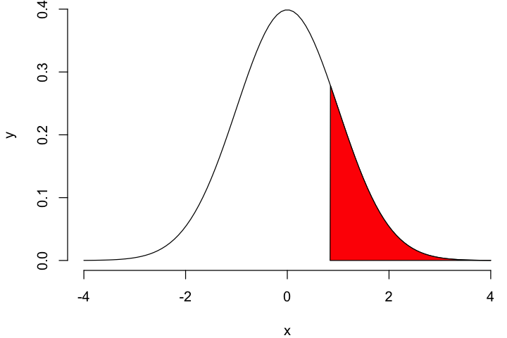

```r
x = seq(-4,4,length.out = 100); y = dnorm(x, mean=0, sd=1)
par(mar=c(4,4,0,0), bty="n"); options(repr.plot.width=6, repr.plot.height=4)
plot(x, y, type='l')
polygon(c( x[x>=pnorm(1)], pnorm(1) ),  c(y[x>=pnorm(1)],0 ), col="red")
```

### Example: The Crash

How extreme was the 1987 crash of $-21.76$\%?

### Probability and Decision

The Secretary Problem: also called the matching or marriage problem

- You will see items (spouses) from a distribution of types $F(x)$.  
  *You clearly would like to pick the maximum*.  
  You see these chronologically.  
  After you decide no, you can't go back and select it.
- Strategy: wait for the length of time $$\frac{1}{e} = \frac{1}{2.718281828} = 0.3678$$

Select after you observe an item greater than the current best.

### Probability and Decision

What's your best strategy?

- Turns out its insensitive to the choice of distribution.
- Although there is the random sample i.i.d. assumption lurking.
- You'll not doubt get married between $18$ and $60$.

Then, pick the next best person!

### Probability and Decision

We are hiring a new VP and are wiling to interview 10 people. Say their rankings are (which we don't know)

```
2  3  6  5  4  8  9  10  1  7
```

In this case, we didn't select the optimal candidate, but we were close.

### Let's run some MC simulations

```r
nmc =5000
n = 1000
sz = 50
rules = round(n*seq(0.1,0.9,length.out = 50))
cnt = rep(0,sz)

i=1
j=1
for (i in 1:sz)
{
  for (j in 1:nmc){
    x = sample(1:n,n)
    screen = x[1:(rules[i]-1)]
    best_screen = max(screen)
    xchoice = x[(rules[i]):n]
    better_candidates = which(xchoice > best_screen)
    if (length(better_candidates)==0) next
    best = xchoice[min(better_candidates)]
    cnt[i] = cnt[i] + (best == max(x))
  }
}
```

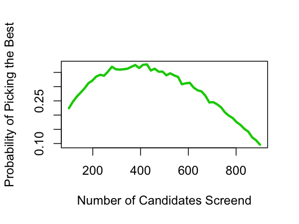

```r
options(repr.plot.res = 150, repr.plot.width=4, repr.plot.height=3)
plot(rules, cnt/nmc, type='l', col=3, lwd=3, xlab="Number of Candidates Screend",
     ylab="Probability of Picking the Best")
```

# Week 2: Bayes

### Topics

This lecture will cover

- Bayes Rule
- Probability and Decision Trees

We'll consider applications to:

1. Business Analytics
2. Artificial Intelligence (AI)

### Bayes and AI

Many applications in social media and business ...

1. Google Translate: $~3$ billion words a day
2. Amazon Alexa: Speech Recogniztion
3. Driveless Car: Waymo

Shannon's autonomous mouse: [Theseus](https://www.youtube.com/watch?v=vPKkXibQXGA)

*Bayes solves these problems!!*

### Bayes Classifier

Output ${\color{blue}{Y}}$ and input ${\color{blue}{X}}$:

$Y:$ image of a cat

$X:$ identify “cat”

Silicon Valley: Season 4:

What's our best decision?

Pick ${\color{blue}{ \hat{Y} }}$ as the *most likely* category given that ${\color{blue}{ X=x}}$, namely $${\color{red}{ \hat{Y} = {\rm arg max}_Y \; p ( Y= y | X = x ) }}$$ I need the probability table ${\color{blue}{p( X=x, Y=y )}}$ and marginal ${\color{blue}{p(X=x)}}$.

### The Game Show Problem

Monte Hall *Let's make a Deal*.

You pick a door.

Monty then opens one of the other two doors, revealing a goat.

Monty can't open your door or show you a car

You have the choice of switching doors.

Is it advantageous to switch?

Assume you pick door $A$ at random. Then $Pr(A) = ( 1 /3 )$.

You need to figure out $pr( A | MB )$ after Monte reveals door $B$ is a goat.

[21 Kevin Spacey: Monte Hall](https://youtu.be/8mSGNRfHSWQ)

### Sensitivity and Specificity

Two errors: An infected person may test negative, a well person tests positive.

Sensitivity $=$ true positive rate (or recall)

% sick people who are correctly identified $P ( T | D )$.

In a perfect world, we'd like $P ( \bar{T} | D ) \approx 0$

Specificity $=$ true negative rate

% of negatives correctly identified as such $P ( \bar{T} | \bar{D} )$.

- Power $=$ sensitivity $=1-\beta$ where $\beta$ is the type II error
- False positive rate, $\alpha =$ type I error $=$ 1 $-$ specificity

### Test Marketing a New Product

Basic Problem:

- Your company is developing a new product and will be test marketing to better gauge the sales of the new product.
- Based on positive, neutral or negative reactions,

  *what are the probability of high and low sales?*

NetFlix [House of Cards](https://www.youtube.com/watch?v=bGQch6VBu1M)

### Test Marketing

Suppose you are given the following information

- New products introduced in the marketplace have high sales 8% of the time and low sales 92% of the time.
- A marketing test has the following accuracies:

  If sales are high, then consumer test reaction is positive 70%, neutral 25% and negative 5%.

  If sales are low, then consumer test reaction is positive 15%, neutral 35% and negative 50%.

### Test Marketing

Step 1: Set-up your notation. Let

$$H = {\rm high \; sales} \; \; L = {\rm low \; sales}$$ $${\rm Pos} = {\rm positive} \; \; {\rm Neu = Neutral} \; \; {\rm Neg} = {\rm Negative}$$

Step 2: List the known conditional probabilities

For the marketing test we have $$\begin{aligned} P( Pos |H ) & = 0.70 , P(Neu|H)=0.25 , P(Neg|H) = 0.05 \\ P( Pos |L ) & = 0.15 , P(Neu|L)=0.35 , P(Neg|L) = 0.50\end{aligned}$$ Finally, the base rates are $P(H) = 0.08$ and $P(L) = 0.92$

### Test Marketing

Step 3: Describe the posterior probabilities that are required:

$$P ( H | Pos )$$ The probability of high sales given a positive marketing test. Compute the probability of a positive test $$\begin{aligned} P(Pos) & = P( Pos| H)P(H) +P(Pos|L)P(L) \\ & = 0.70 \times 0.08 + 0.15 \times 0.92 = 0.194\end{aligned}$$

### Test Marketing

Now use Bayes Rule

$$\begin{aligned} P( H| Pos) & = \frac{ P( Pos |H)P(H)}{P(Pos)} \\ & = \frac{0.70 \times 0.08}{ 0.194} = 0.288\end{aligned}$$ Hence 28.8% you'll have high sales in the market.

We should interpret this to our initial probability of only $8$%.

### Two Headed Coin

Large jar containing $1024$ fair coins and one two-headed coin.

- You pick one at random and flip it $10$ times and get all heads.
- What's the probability that the coin is the two-headed coin?

$\frac{1}{1025}$ probability of initially picking the two headed coin.

$\frac{1}{1024}$ chance of getting $10$ heads in a row from a fair coin

Therefore, it's a $50/50$ bet.

### Two Headed Coin

Let $E$ be the event that you get $10$ Heads in a row $$P \left ( {\rm two \; headed} | E \right ) = \frac{ P \left ( E | {\rm two \; headed} \right )P \left ( {\rm two \; headed} \right )} {P \left ( E | {\rm fair} \right )P \left ( {\rm fair} \right ) + P \left ( E | {\rm two \; headed} \right )P \left ( {\rm two \; headed} \right )}$$ Therefore, the posterior probability $$P \left ( {\rm two \; headed} | E \right ) = \frac{ 1 \times \frac{1}{1025} }{ \frac{1}{1024} \times \frac{1024}{1025} + 1 \times \frac{1}{1025} } = 0.50$$

### Next Toss?

What's the probability that the next toss is a head?

- Using the law of total probability gives $$\begin{aligned} P( H |E ) &= P( H | {\rm two \; headed} )P( {\rm two \; headed} |E ) + P( H | {\rm fair} )P( {\rm fair} |E) \\ & = 1 \times \frac{1}{2} + \frac{1}{2} \times \frac{1}{2} \\ & = \frac{3}{4}\end{aligned}$$

### The Marble Game

Two players $A$ and $B$ play a marble game.

- Each player has both a red and a blue marble. They present one marble to each other.

Payoff Matrix

```
1.  If both present red, $A$ wins $3.

2.  If both present blue, $A$ wins $1.

3.  If the colours do not match, $B$ wins \$2
```

- Is it better to be $A$ or $B$ or does it matter?

### The Marble Game

If players have a $\frac{1}{2} $ probability of playing Red or Blue

- Thus each player has the same expected payoff $E( A) = \$1$ $$\begin{aligned} E(A) &= (1/4)(3) + (1/4)(1) =1 \\ E(B) &= (1/4)(2) + (1/4)(2) =1\end{aligned}$$
- Player $A$ and $B$'s variances are $$\begin{aligned} Var (A) & = (1-1)^2 (1/4) +(3-1)^2 (1/4) + (0-1)^2 (1/2) = 1.5 \\ Var(B) & = (2-1)^2 (1/2) + (0-1)^2 (1/2) = 1\end{aligned}$$
- If you are risk averse, player $B$ position is favored

### The Marble Game

The matrix of probabilities is equally likely

| $(A,B)$ | Probability |
| --- | --- |
| $P( red, red )$ | (1/2)(1/2)=1/4 |
| $P( red, blue )$ | (1/2)(1/2)=1/4 |
| $P( blue, red )$ | (1/2)(1/2)=1/4 |
| $P( blue, blue )$ | (1/2)(1/2)=1/4 |

### Optimal Strategy

What if they decide not to play $50/50$?

- Then there’s a mixed strategy (randomized) that is a Nash equilibrium that is, both players won’t deviate from the strategy.
- We’ll see the the following equilibrium happens
  1. $A$ plays Red with probability $(1/2)$ and blue $(1/2)$
  2. $B$ plays Red with probability $(1/4)$ and blue $(3/4)$

### Probability Matrix

Nash equilibrium probabilities

- We have: $p=P( A \; red )= 1/2, p_1 = P( B \; red ) = 1/4$

| $(A,B)$ | Probability |
| --- | --- |
| $P( red, red )$ | (1/2)(1/4)=1/8 |
| $P( red, blue )$ | (1/2)(3/4)=3/8 |
| $P( blue, red )$ | (1/2)(1/4)=1/8 |
| $P( blue, blue )$ | (1/2)(3/4)=3/8 |

### Expected payoff

Expected payoff to playing Red equals that of playing Blue for both.

- $A$'s expected payoff is $\frac{3}{4}$ and $B$'s is \$1

  $$\begin{aligned} E(A) & = (1/8)(3) + (3/8)(1) = 3/4 \\ E(B) & =1 \end{aligned}$$
- $B$ is the favored position.

### Optimal Strategy

We have general payoffs: $p=P( A \; red ), p_1 = P( B \; red )$ $$\begin{aligned} f_A ( p , p_1 ) &=& 3 p p_1 + ( 1 -p ) ( 1 - p_1 ) \\ f_B ( p , p_1 ) &=& 2 \{ p(1 - p_1) + ( 1 -p ) p_1 \}\end{aligned}$$ To find the equilibrium point $$\begin{aligned} ( \partial / \partial p ) f_A ( p , p_1 ) &=& 3 p_1 - ( 1 - p_1 ) = 4 p_1 -1 \; \; {\rm so} \; \; p_1= 1/4 \\ ( \partial / \partial p_1 ) f_B ( p , p_1 ) &=& 2 ( 1 - 2p ) \; \; {\rm so} \; \; p= 1/2\end{aligned}$$

### Decision Trees

### Catastrophe Modeling

You live in a house that is somewhat prone to mud slides.

- Each rainy season there is a 1\% chance of a mud slide occurring. - You estimate that a mud slide would do \$1 million in damage.
- You have the option of building a retaining wall that would help reduce the chance of a devastating mud slide.

The wall costs \$40,000 to build, and if the slide occurs, the wall will hold with a 95\% probability.

- You also have the option of a Geologist's opinion.

Should you build the wall?

Should you use the Geologist's Test and Bayes Rule?

### Decision Tree

Let's formally solve this as follows:

- Build a decision tree.
- The tree will list the probabilities at each node. It will also list any costs there are you going down a particular branch.
- Finally, it will list the expected cost of going down each branch, so we can see which one has the better risk/reward characteristics.

There's also the possibility of a further test to see if the wall will hold.

### Testing

Let's include the testing option

- You also have the option of having a test done to determine whether or not a slide will occur in your location.
- The test costs \$3000 and has the following accuracies.

  $$P( T | {\rm Slide} ) = 0.90 \; \; {\rm and } \; \; P( \bar{T} | {\rm No \; Slide} ) = 0.85$$

If you choose the test, then should you build the wall?

### Bayes Rule

Bayes Rule is as follows:

- The initial prior probabilities are $$P( Slide ) = 0.01 \; \; {\rm and} \; \; P ( {\rm No \; Slide} ) = 0.99$$
- Therefore $$\begin{aligned} P( T) & = P( T | {\rm Slide} ) P( {\rm Slide} ) + P( T | {\rm No \; Slide} ) P( {\rm No \; Slide} ) \\ P(T)& = 0.90 \times 0.01 + 0.15 \times 0.99 = 0.1575\end{aligned}$$ We'll use this to find our optimal course of action.

### Bayes Probabilities

#### $P(Slide|T)$

The Bayes probability given a positive test is $$\begin{aligned} P ( Slide | T ) & = \frac{ P ( T | Slide ) P ( Slide )}{P(T)} \\ & = \frac{ 0.90 \times 0.01}{ 0.1575} = 0.0571\end{aligned}$$

### Bayes Probabilities

#### $P(Slide| Not \; T )$

The Bayes probability given a negative test is $$\begin{aligned} P \left ( {\rm Slide} | \bar{T} \right ) & = \frac{ P ( \bar{T} | {\rm Slide} ) P ( {\rm Slide} )}{P(\bar{T})} \\ & = \frac{0.1 \times 0.01 }{0.8425} \\ & =0.001187\end{aligned}$$

Compare this to the initial base rate of a $1$% chance of having a mud slide.

### Probability Lose Everything

You build the wall without testing, what's the probability that you lose everything?

With the given situation, there is one path (or sequence of events and decisions) that leads to losing everything:

1. Build without testing (given)
2. Slide ($0.01$)
3. Doesn't hold ($0.05$)

$$P ( {\rm losing} \; {\rm everything} | {\rm build} \; {\rm w/o} \; {\rm testing} ) = 0.01 \times 0.05 = 0.0005$$

### Probability Lose Everything

You choose the test, what's the probability that you'll lose everything?

There are two paths that lead to losing everything:

- First Path: There are three things that have to happen to lose everything

  Test +ve ($P=0.1575$), Build, Slide ($P= 0.0571$), Doesn't Hold ($P=0.05$)
- Second Path: Now you lose everything if

  Test -ve ($P=0.8425$), Don't Build, Slide given negative ($P=0.001187$)

### Conditional Probabilities

- For the first path $$P ( {\rm first} \; {\rm path} ) = 0.1575 \times 0.0571 \times 0.05 = 0.00045$$
- For the path $$P ( {\rm second} \; {\rm path} ) = 0.8425 \times 0.001187 = 0.00101$$

Hence putting it all together $$P ( {\rm losing} \; {\rm everything} | {\rm testing} ) = 0.00045 + 0.00101 = {\color{red}{0.00146}}$$

### Risk and Reward

| Choice | Expected Cost | Risk | P |
| --- | --- | --- | --- |
| Don't Build | \$10,000 | 0.01 | 1 in 100 |
| Build w/o testing | \$40,500 | 0.0005 | 1 in 2000 |
| Test | \$10,760 | 0.00146 | 1 in 700 |

Expected Cost: Fee + Build + Loss

Expected cost: $3 + 40\times 0.1575+ 1000\times 0.00146$ or \$ $10,760$

What do you choose?

### Summary

Probability and Random variables

- Joint Probability tables
- Bayes rule
- Decision Trees